# MAT150 - Summer 2023

Phd. Anabela Romina Turlione

Digipen, Bilbao

# Continuity

When is a function continouous?

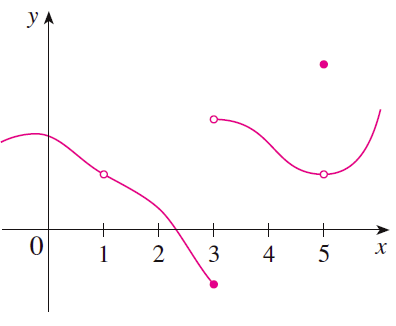

Geometrically, you can think of a function that is continuous at every number in an interval as a function whose graph has no break in it. The graph can be drawn without removing your pen from the paper.

## Definition

function is **continuous at a number $a$** if

\begin{equation} \lim_{x\to a} f(x) = f(a) \end{equation}

This deifinition requires three things:

1. $f(a)$ is defined (that is, $a$ is in the domain of $f$). </br>
2. $lim_{x\to a} f(x)$ exists </br>
3. $lim_{x\to a} f(x)=f(a)$

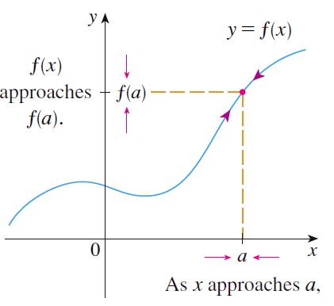

- A continuous function $f$ has the property that a small change in $x$ produces only a small change in $f$. </br>
- The change in $f$ can be kept as small as we please by keeping the change in $x$ sufficiently small.

We say that $f$ is **discontinuous at $a$** (or has a **discontinuity** at $a$) if $f$ is not continuous at $a$.

Here are some more examples of discontinuity:

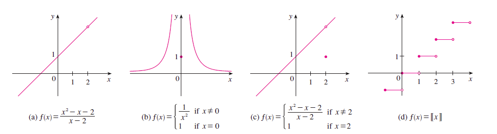

A function is **continuous from the right at a number $a$** if

\begin{equation} \lim_{x\to a^+} f(x) = f(a) \end{equation}

and is **continuous from the left at $a$** if

\begin{equation} \lim_{x\to a^-} f(x) = f(a) \end{equation}

A function is **continuous on an interval** if it is continuous at every number in the interval. (If f is defined only on one side of an endpoint of the interval, we understand *continuous* at the endpoint to mean *continuous from the right or continuous from the left*.)

If $f$ and $g$ are continuous at $a$ and $c$ is a constant, then the following functions are also continuous at $a$:

1. $f+g$ </br>
2. $f-g$ </br>
3. $cf$ </br>
4. $fg$ </br>
5. $ \Large{\frac{f}{g}}$ if $g(a)\ne 0$

## Theorem

The following types of functions are continuous at every number in their domains:

1. Polynomials </br>
2. Rational functions </br>
3. Root functions </br>
4. Trigonometric functions </br>
5. Inverse trigonometric functions </br>
6. Exponential functions </br>
7. Logarithmic functions

## Theorem

\begin{equation} \lim_{x\to a} f\big(g(x)\big) = f\big(\lim_{x\to a} g(x)\big) \end{equation}

**Exercise 1**

Study the continuity of the following functions:

a.

\begin{equation} f(x)=\left\lbrace \begin{array}{ll} \sqrt{x-4}, ~~ x> 4 \\ 1,~~ x = 4 \\ 8-2x, ~~ x < 4 \end{array} \right. \end{equation}

b.

\begin{equation} f(x)=\frac{|x|}{x} \end{equation}

c.

\begin{equation} f(x)=\left\lbrace \begin{array}{ll} -\sqrt{9-x^2}, ~~ 0\le x \le 3 \\ 1-|x-4|,~~ 3<x \le 5 \end{array} \right. \end{equation}

d. Find $a,~b$ so that the function is continuous.

\begin{equation} f(x)=\left\lbrace \begin{array}{ll} \frac{x^2-4}{x-2}, ~~ x< 2 \\ ax^2-bx+3,~~ 2 \le x <3 \\ 2x-a+b, ~~ x \ge 3 \end{array} \right. \end{equation}

## Theorem

If $g$ is continuous at $a$ and $f$ is continuous at $g(a)$, then the composite function $f\circ g$ given by $(f\circ g) (x)=f\big(g(x)\big)$ is continuous at $a$.

In other words: “a continuous function of a continuous function is a continuous function.”

**Exercise 2**

Where is $F(x)$ continuous?

$F(x)=\ln(1+\cos x)$

```python
import matplotlib.pyplot as plt
import numpy as np

def plot1():
    x=np.linspace(-10.2,10.2,1000)

    plt.plot(x,np.log(1+np.cos(x)))
    plt.ylim(-5,2)
    plt.xlim(-10.1,10.1)
    plt.axvline(x = 0, color = 'k')
    plt.axhline(y = 0, color = 'k')
    plt.axvline(x = np.pi, color = 'tab:orange', linestyle = '--')
    plt.axvline(x = 3*np.pi, color = 'tab:orange', linestyle = '--')
    plt.axvline(x = -np.pi, color = 'tab:orange', linestyle = '--')
    plt.axvline(x = -3*np.pi, color = 'tab:orange', linestyle = '--')

    plt.annotate('$x=\pi$',xy=(np.pi+0.1,1.5), color='tab:orange')
    plt.annotate('$x=3\pi$',xy=(3*np.pi-2,1.5), color='tab:orange')
    plt.annotate('$x=-\pi$',xy=(-np.pi+0.1,1.5), color='tab:orange')
    plt.annotate('$x=-3\pi$',xy=(-3*np.pi+0.1,1.5), color='tab:orange')
```

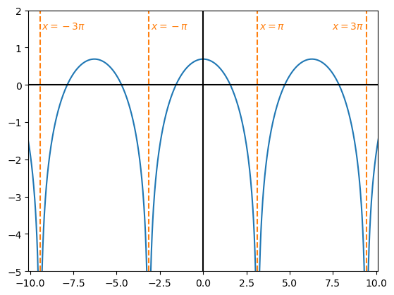

```python
plot1()
```

## THE INTERMEDIATE VALUE THEOREM

Suppose that $f$ is continuous on the closed interval $[a,b]$ and let $N$ be any number between $f(a)$ and $f(b)$, where $f(a)\ne f(b)$. Then there exists a number $c$ in $(a,b)$ such that $f(c)=N$.

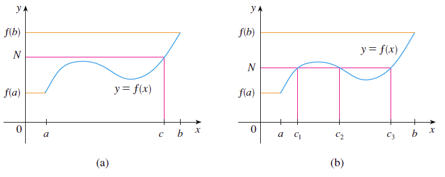

One use of the Intermediate Value Theorem is in locating roots of equations:

**Exercise 3**

Show that there is a root of the equation

\begin{equation} 4x^3-6x^2+3x-2=0 \end{equation}

between 1 and 2.

# Continuity in $\Re^3$

A function $f$ of two variables is called **continuous at** $(a,b)$ if

\begin{equation} \lim_{(x,y)\to (a,b)} f(x,y) =f(a,b) \end{equation}

We say $f$ is continuous on $D$ if is continuous at every point $(a,b)$ in $D$.

**Exercise 4**

Study the continuity of the function

\begin{equation} f(x,y)=\left\lbrace \begin{array}{ll} \frac{2xy}{x^2+2y^2}, ~~ {x\in(-\infty,1],y\in(-\infty,1) }\\ \frac{1-xy}{1-(xy)^4}, ~~ {x\in(1,\infty),y\in [1,\infty) } \end{array} \right. \end{equation}

# The tangent problem

A tangent to a curve is a line that touches the curve.

Tangent to a circle:

Line that intersects the circle once and only once.

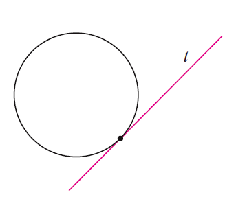

For more complicated curves this definition is inadequate:

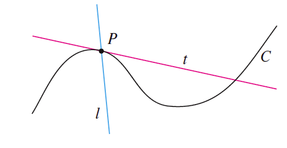

## Example

- We need the the slope of the line $m$ at (0.5,0.25).
- We need 2 points to calculate a slope.
- We can compute an approximation to $m$ by choosing a nerby point $Q=(x,x^2)$

\begin{equation} m_{PQ}=\frac{x^2-0.25}{x-0.5} \end{equation}

- The line defined by the points $P$ and $Q$ is the *secant line*

```python
import matplotlib.pyplot as plt
import numpy as np

def tangent(x0,x1,zoom):
    x=np.linspace(-10.2,10.2,1000)
    msec=(x1**2-x0**2)/(x1-x0)
    m=2*x0

    plt.plot(x,x**2)

    if zoom:
        plt.ylim(-0.1,2)
        plt.xlim(0,2)
    else:
        plt.ylim(-0.1,2)
        plt.xlim(-1,2)

    plt.axvline(x = 0, color = 'k')
    plt.axhline(y = 0, color = 'k')
    plt.plot(x0,x0**2,'o')
    plt.annotate('$P({},{})$'.format(x0,round(x0**2,2)),xy=(x0+0.1,x0**2), color='tab:orange')
    plt.plot(x,msec*(x-x0)+x0**2, '--', color='tab:orange')
    plt.plot(x,m*(x-x0)+x0**2)

    plt.plot(x1,x1**2,'o',color='tab:orange')
    plt.annotate('$Q({},{})$'.format(x1,round(x1**2,2)),xy=(x1-0.3,x1**2+0.1), color='tab:orange')
```

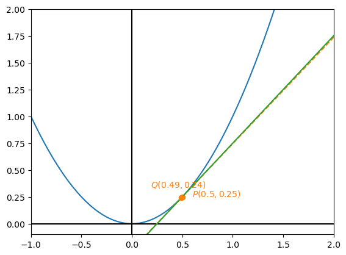

```python
tangent(x0=0.5,x1=0.49,zoom=False)
```

We say that the slope of the tangent line is the limit of the slopes of the secant lines, and we express this symbolically by writing

\begin{equation} \lim_{Q\to P} m_{PQ} = m \end{equation}

Then if $P=(x_0,y_0)$,

\begin{equation} m=\lim_{x\to x_0} m_{PQ} = \lim_{x\to x_0}\frac{x^2-x^2_0}{x-x_0}=2x_0 \end{equation}

We use the point-slope form of the equation of a line to write the equation of the tangent line through as

\begin{equation} y=2x_0(x-x_0)+x^2_0 \end{equation}

Then, if we want to find the tangent line a curve $C$ that has equation $y=f(x)$ in the point $P(a,f(a))$:

1. We compute the slope of the secant line defined by the points $P$ and $q(x,f(x))$, taking $x\ne a$:

\begin{equation} m_{sec}=\frac{f(x)-f(a)}{x-a} \end{equation}

1. We let $Q$ approach $P$ along the curve by letting $x$ approach $a$.

\begin{equation} m=\lim_{x\to a}\frac{f(x)-f(a)}{x-a} \end{equation}

## Definition

The **tangent line** to the curve $y=f(x)$ at the point $P(a,f(a))$ is the line through $P$ with slope

\begin{equation} m=\lim_{x\to a}\frac{f(x)-f(a)}{x-a} \end{equation}

provided that this limit exists.

Equivalently, if $\Delta x=x-a$ then $x=a+\Delta x$

\begin{equation} m=\lim_{\Delta x\to 0}\frac{f(a+\Delta x)-f(a)}{\Delta x} \end{equation}

## Definition

The **derivative of a function $f$ at a number $a$**, denoted by $f'(a)$, is

\begin{equation} f'(a)=\lim_{\Delta x\to 0}\frac{f(a+\Delta x)-f(a)}{\Delta x} \end{equation}

if this limit exists.

Equivalently,

\begin{equation} f'(a)=\lim_{x\to a}\frac{f(x)-f(a)}{x-a} \end{equation}

## Definition

A function is **differentiable at $a$** if $f'(a)$ exists. It is **differentiable on an open interval** $(a,b)$ (or $(a,\infty)$ or $(-\infty,a)$ or $(-\infty,\infty)$) if it is differentiable at every number in the interval.

## Definition

The tangent line to $y=f(x)$ at the point $(a,f(a))$ is the line through $(a,f(a))$ whose slope is equal to $f'(a)$, the derivative of $f$ at $a$.

## Rates of change

Suppose $y$ is a function of $x$, $y=f(x)$. if $x$ changes from $x_1$ to $x_2$, then the change in x is

\begin{equation} \Delta x=x_2-x_1 \end{equation}

The corresponding change in $y$ is:

\begin{equation} \Delta y=f(x_2)-f(x_1) \end{equation}

The difference quotient

\begin{equation} \frac{\Delta y}{\Delta x}=\frac{f(x_2)-f(x_1)}{x_2-x_1} \end{equation}

is called the **average rate of change of $y$ with respect to $x$** over the interval $[x_1,x_2]$ and can be interpreted as the slope of the secant line $PQ$.

The **instantaneous rate of change is**

\begin{equation} \lim_{\Delta x\to 0}\frac{\Delta y}{\Delta x}=\lim_{x_2\to x_1}\frac{f(x_2)-f(x_1)}{x_2-x_1}=f'(x_1) \end{equation}

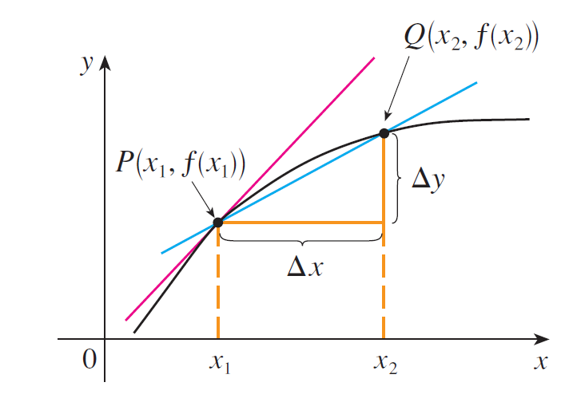

For example, the **average velocity** is the average rate of change of the position $x$ respect to the time $t$, that is, the variation of the position in a certain time interval.

\begin{equation} v_{AV}=\frac{x-x_0}{t-t_0}=\frac{\Delta x}{\Delta t} \end{equation}

Where $x$ is a function of the time: $x=x(t)$.

The **instantaneous velocity** is the velocy at a certain time and it is calculated by taking a "very small" time interval:

\begin{equation} v=\lim_{t \to t_0}\frac{x(t)-x(t_0)}{t-t_0}\lim_{\Delta t \to 0}\frac{\Delta x}{\Delta t}=x'(t) \end{equation}

This means that the velocity at time $t_0$ is equal to the slope of the tangent line at $P(t_0,x_0)$ and it is the derivative of the position respect to the time at $t_0$

- If $s=f(t)$ is the position function of a particle that moves along a straight line, then $f'(t_0)$ is the rate of change of the displacement $s$ with respect to the time at $t_0$.
- In other words, $f'(t_0)$ is the velocity of the particle at $t_0$.
- $|f'(t_0)|$ is the speed.
- When the derivative is large, the curve is steep and the values of $y$ change rapidly.

Another notation for the derivative:

\begin{equation} f'(a)=\lim_{\Delta x\to 0}\frac{\Delta y}{\Delta x}=\frac{d y}{d x}\big|_{x=a} \end{equation}

## THE DERIVATIVE AS A FUNCTION

If we calculate the derivative at an arbitrary point $x$, we can define a new function:

\begin{equation} f'(x)=\lim_{\Delta x\to 0}\frac{f(x+\Delta x)-f(x)}{\Delta x} \end{equation}

$f'(x)$ is **the derivative of** $f$

**EXAMPLE 1** The graph of a function $f$ is given in the figure. Use it to sketch the graph of the derivative $f'$

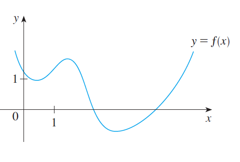

Solution:

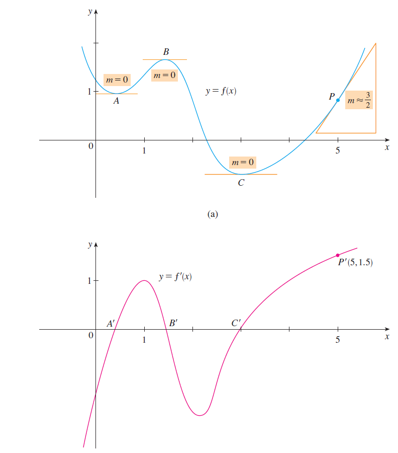

**Exercise 1**

Find the derivatives of the functions applying its definition.

a.

\begin{equation} f(x)=5 \end{equation}

b.

\begin{equation} f(x)=x \end{equation}

c.

\begin{equation} f(x)=x^2 \end{equation}

d.

\begin{equation} f(x)=x^3 \end{equation}

e.

\begin{equation} f(x)=x^n \end{equation}

f.

\begin{equation} f(x)=\sqrt{x} \end{equation}

g.

\begin{equation} f(x)=1/x \end{equation}

h.

\begin{equation} f(x)=\sin(x) \end{equation}

i.

\begin{equation} f(x)=\cos(x) \end{equation}

## The derivative of the addition/substraction

\begin{equation} \big(f+g\big)'(x)=~? \end{equation}

\begin{equation} \big(f+g\big)'(x)=\lim_{\Delta x \to 0}\frac{\big(f+g\big)(x+\Delta x)-\big(f+g\big)(x)}{\Delta x}= \end{equation}

\begin{equation} =\lim_{\Delta x \to 0}\frac{f(x+\Delta x)+g(x+\Delta x)-f(x)-g(x)}{\Delta x} \end{equation}

\begin{equation} =\lim_{\Delta x \to 0}\frac{f(x+\Delta x)-f(x)}{\Delta x}+\lim_{\Delta x \to 0}\frac{g(x+\Delta x)-g(x)}{\Delta x}=f'(x)+g'(x) \end{equation}

## The derivative of the product

\begin{equation} \big(f\cdot g\big)'(x)=~? \end{equation}

\begin{equation} =\lim_{\Delta x \to 0}\frac{f(x+\Delta x)\cdot g(x+\Delta x)-f(x)\cdot g(x)}{\Delta x} \end{equation}

if

\begin{equation} f(x+\Delta x)=f(x)+\Delta f \end{equation}\begin{equation} g(x+\Delta x)=g(x)+\Delta g \end{equation}

\begin{equation} \big(f\cdot g\big)'(x)=\lim_{\Delta x \to 0}\frac{\big(f(x)+\Delta f\big)\cdot \big(g(x)+\Delta g\big)-f(x)\cdot g(x)}{\Delta x} \end{equation}

\begin{equation} \big(f\cdot g\big)'(x)=\lim_{\Delta x \to 0}\frac{f(x) \cdot g(x) +\Delta f \cdot g(x) +f(x) \Delta g +\Delta f \Delta g -f(x)\cdot g(x)}{\Delta x}= \end{equation}

\begin{equation} \big(f\cdot g\big)'(x)=\lim_{\Delta x \to 0}\frac{\Delta f \cdot g(x) +f(x) \Delta g +\Delta f \Delta g }{\Delta x}= \end{equation}

\begin{equation} \big(f\cdot g\big)'(x)=\lim_{\Delta x \to 0}\bigg(\frac{\Delta f}{\Delta x}\cdot g(x)+f(x) \frac{\Delta g}{\Delta x}+\frac{\Delta f \Delta g}{\Delta x}\bigg)= \end{equation}

\begin{equation} \big(f\cdot g\big)'(x)=\lim_{\Delta x \to 0}\bigg(\frac{\Delta f}{\Delta x}\cdot g(x)+f(x) \frac{\Delta g}{\Delta x}+\frac{\Delta f \Delta g \Delta x}{\Delta x \Delta x}\bigg)=f(x)\cdot g'(x)+g(x)\cdot f'(x) \end{equation}

since \begin{equation} \lim_{\Delta x \to 0}\frac{\Delta f \Delta g \Delta x}{\Delta x \Delta x}=f'(x)\cdot g'(x) \cdot 0=0 \end{equation}

## The derivative of the division

Similarly...

\begin{equation} \big(f \big / g\big)'(x)=...=\frac{f'(x)\cdot g(x)-g'(x)\cdot f(x)}{g^2(x)},~~~ g(x)\ne 0 \end{equation}

You can consider that $f(x) \big / g(x)=f(x)\cdot \big(1\big/ g(x)\big)$ and apply the derivative of the product.

**Exercise 2**

Find $f'(x)$ for the following functions:

a.

\begin{equation} f(x)=tan(x) \end{equation}

b.

\begin{equation} f(x)=cos(x-3) \end{equation}

c.

\begin{equation} f(x)=\frac{2}{\sqrt{x+1}} \end{equation}

d.

\begin{equation} f(x)=\frac{\sin(x-3)}{x+1}~~~~ using ~ the~ definition \end{equation}

e.

\begin{equation} f(x)=\ln(x), ~~~ hint:~ \ln\big(f(x)\big)\approx f(x)-1 ~~~ when ~~~ f(x) \to 1 \end{equation}

f.

\begin{equation} f(x)=e^x, ~~~ hint:~Change~of~variable~~~ t=e^{\Delta x}-1 \end{equation}

g.

\begin{equation} f(x)=2^x \end{equation}

h.

\begin{equation} f(x)=e^{3x}\cdot \big(x^2+1\big) \end{equation}

i.

\begin{equation} f(x)=\ln(x)\cdot (x+1) \end{equation}

## Relation between continuity and differentiability

## Theorem

if $f(x)$ is **differentiable**, then $f(x)$ is continuous.

**differentiability** $\Rightarrow$ **continuity** but the oposite is not true.

**Proof**

On whiteboard..

## The study of differentiability

### HOW CAN A FUNCTION FAIL TO BE DIFFERENTIABLE?

- If the graph of a function has a “corner” or “kink” in it, then the graph of has no tangent at this point and is not differentiable there.
- if $f$ is not continuous at $a$, then $f$ is not differentiable at $a$.
- A third possibility is that the curve has a **vertical tangent line** when $x=a$; that is, $f$ is continuous at $a$ and

\begin{equation} \lim_{x\to a}┃f'(x)┃=\infty \end{equation}

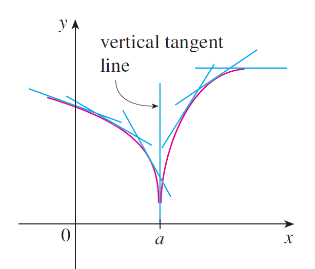

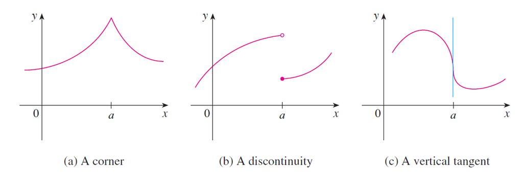

## Theorem

f(x) is differentiable if f’(x) is continuous

**Exercise 3**

a. Sketch and study the differentiability of $f(x)=┃x┃$

b. Study the differentiability of

\begin{equation} f(x)=\left\lbrace \begin{array}{ll} x^2+2, ~~ x\le 1 \\ x^3-x+3,~~ x >1 \end{array} \right. \end{equation}

c. Find the value of a and b so that the function is differentiable everywhere:

\begin{equation} f(x)=\left\lbrace \begin{array}{ll} ax+b, ~~ x\ge 0 \\ 2\sin x,~~ x < 0 \end{array} \right. \end{equation}

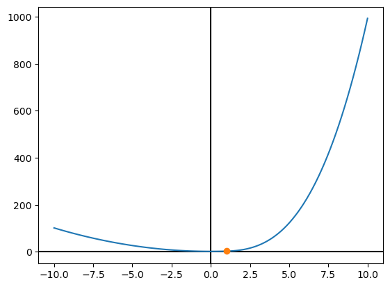

```python
# plot for b
import matplotlib.pyplot as plt
import numpy as np

x1 = np.linspace(-10,1)
x2 = np.linspace(1,10)

plt.axvline(x = 0, color = 'k')
plt.axhline(y = 0, color = 'k')
plt.plot(x1,x1**2+2)
plt.plot(x2,x2**3-x2+3, color = 'tab:blue')
plt.plot(1,3,'o')
```

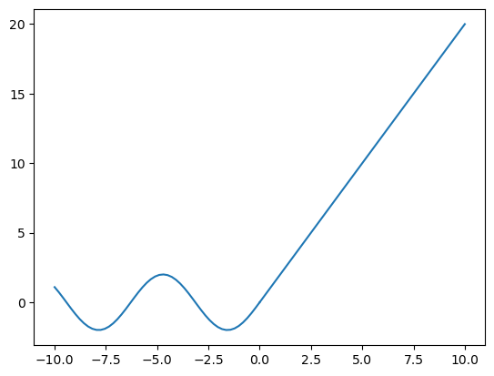

```python
# plot for b
import matplotlib.pyplot as plt
import numpy as np

x1 = np.linspace(-10,0)
x2 = np.linspace(0,10)

# plt.axvline(x = 0, color = 'k')
# plt.axhline(y = 0, color = 'k')
plt.plot(x1,2*np.sin(x1))
plt.plot(x2,2*x2, color = 'tab:blue')
# plt.plot(0,0,'o')
```

## Diferentiation Rules Summary

DERIVATIVE OF A CONSTANT FUNCTION

\begin{equation} \frac{d}{dx}\big(c\big)=0 \end{equation}

THE POWER RULE

\begin{equation} \frac{d}{dx}\big[x^n\big]=nx^{n-1},~~~ n~ is~ any~ real~ number \end{equation}

THE CONSTANT MULTIPLE RULE

\begin{equation} \frac{d}{dx}\big[cf(x)\big]=c \frac{d}{dx}f(x) \end{equation}

THE SUM RULE

\begin{equation} \frac{d}{dx}\big[f(x)+g(x)\big]= \frac{d}{dx}f(x)+\frac{d}{dx}g(x) \end{equation}

THE DIFFERENCE RULE

\begin{equation} \frac{d}{dx}\big[f(x)-g(x)\big]= \frac{d}{dx}f(x)-\frac{d}{dx}g(x) \end{equation}

THE PRODUCT RULE

\begin{equation} \frac{d}{dx}\big[f(x)\cdot g(x)\big]= \frac{d}{dx}f(x)\cdot g(x)+f(x)\cdot \frac{d}{dx}g(x) \end{equation}

THE QUOTIENT RULE

\begin{equation} \frac{d}{dx}\bigg[\frac{f(x)}{g(x)}\bigg]= \frac{\frac{d}{dx}f(x)\cdot g(x)-f(x)\cdot \frac{d}{dx}g(x)}{\big[g(x)\big]^2} \end{equation}

DERIVATIVE OF THE NATURAL EXPONENTIAL FUNCTION

\begin{equation} \frac{d}{dx}\big(e^x\big)= e^x \end{equation}

DERIVATIVE OF THE NATURAL LOGARITHM

\begin{equation} \frac{d}{dx}\big[\ln(x)\big]= \frac{1}{x},~~~ x >0 \end{equation}

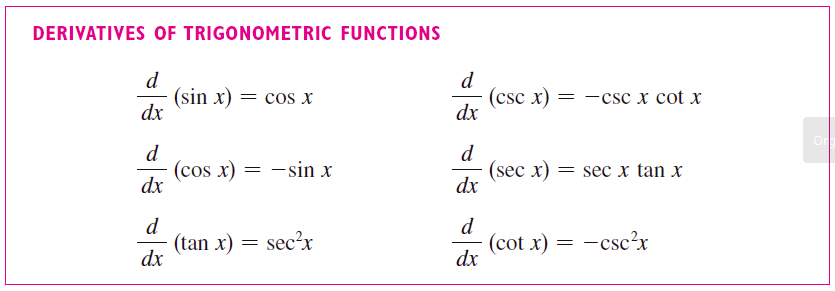